# Gaussian process models

Eric Kalosa-Kenyon

17 June 2017

Abstract

In this report, I show some basic theory and applications for gaussian processes.

# Introduction

## Deffinition of a gaussian process

A gaussian process $GP$ over a set $S$ is a continuum of random variables $X_{\tau^\star} = \{X_\tau\}$ for $\tau\in\tau^\star\subset\mathbf{R}$ where any finite subset $X_T$ where $T = \{t_1,\dots,t_n\}$ where $t_i\in\tau^\star$ for all $i\in\{1,\dots,n\}$ are jointly distributed according to a multivariate gaussian distribution. You can think about this like a distributions over functions over $S$. First, I will consider $S=\mathbf{R}$, forcing the gaussian process to induce a distribution over functions over the reals. A handful of draws from this induced distribution are depicted below.

## Baby’s first visualization

Below I depict discretized draws from a gaussian process.

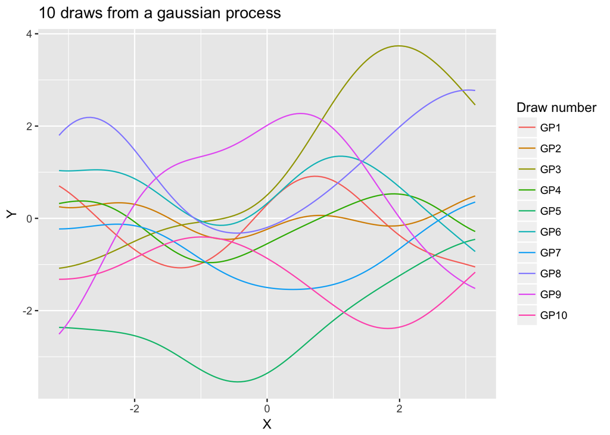

```r
# Parameters
t = c(-pi,pi) # plotting range
D = 20*floor(abs(t[1]-t[2])) # number of evenlt spaced collocation points
K = 10 # number of curves
lkern = 2 # kernel length-scale hyperparameter
sigkern = 1.6 # kernel varaince hyperparameter

# Define kernel
kernel_sel = function(x0, x1){
    # Using squared exponential loss
    return(sigkern^2 * exp(-1/2 * (x0-x1)^2 / lkern))
}

# Define mean function
mu = function(x){
    # Constant mean
    return(0*x)
}

# Collocate X values
xs = seq(t[1], t[2], length.out=D)

# Calculate covariance matrix
S = outer(xs, xs, kernel_sel)

# Draw joint multivariate gaussian samples
ys = t(mvrnorm(K, mu = mu(xs), Sigma=S))

# Plot
plt_df = data.frame(x=xs, y=ys)
names(plt_df) = c("x", paste("GP", 1:K, sep=""))
plt_df_m = melt(plt_df, id=c("x"))
plt = ggplot(plt_df_m) +
    geom_line(aes(x=x, y=value, color=variable)) +
    labs(x="X", y="Y",
         title=paste(K, "draws from a gaussian process"),
         color="Draw number")
```

You may notice, browsing this code or perceptively reading the introduction, that I’ve left a bit out of the specification of the particular gaussian process depicted above.

## A bit more on the deffiniton

A key to the behavior of the process is its covariance kernel. Here, I used a cannonical exponential squared loss $k(x_1, x_2) = e^{-\sigma((x_1-x_2)/\ell)^2}$ with a couple tuning hyperparameters $\sigma$ and $\ell$. Computing the outer product of the $x$ values of interest (here just $D=120$ points equally spaced between $-3.1415927$ and $3.1415927$) using the kernel yeilds a $D\times D$ covariance matrix.

An important point here is that each discretized point on the $X$ axis is, in the eyes of the gaussian process, an orthogonal dimension. Thus induced by the gaussian process is a multivariate normal distribution over $D$ variables. The covariance of these dimensions is induced by the kernel, and in this case, under the exponential squared loss, that means that points close in the natural space are highly correlated dimensions in the induced distribution. It’s this property that gives us the probability of a particular function being drawn from the induced distribution proportional to its smoothness.

## An alternative kernel

Before I get too stuck on the exponential square loss, however useful and traditional it may be, it’s important to look at different kernels. These different kernels will yeild different covariance matricies, but all kerenels share an important property: they induce positive semidefinite covariance matricies. If this semidefinite stuff is meaningless to you, look it up, but also it basically means that the kernel induces a non-negative way to measure distances between points in the natural space. It’s not a metric, but it’s still useful to think about the particular square exponential loss kernel like a measuring stick - it gives high values for close things, and low values for far things.

Now, this isn’t neccessarily true for a kernel - remember that it just has to induce positive semidefinite covaraince matricies. To drive this home let’s look at a different kernel:

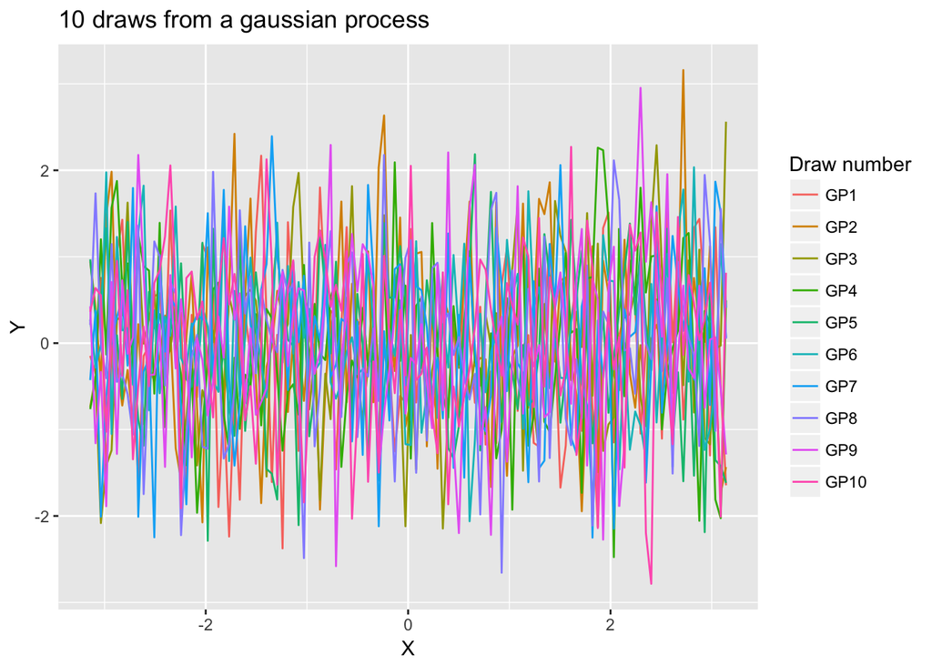

```r
kernel_01 = function(x0, x1){
    # Using 0-1 loss
    return((x0 == x1) + 0)
}

# Calculate covariance matrix
S = outer(xs, xs, kernel_01)

# Draw joint multivariate gaussian samples
ys = t(mvrnorm(K, mu = mu(xs), Sigma=S))

# Plot
plt_df = data.frame(x=xs, y=ys)
names(plt_df) = c("x", paste("GP", 1:K, sep=""))
plt_df_m = melt(plt_df, id=c("x"))
plt = ggplot(plt_df_m) +
    geom_line(aes(x=x, y=value, color=variable)) +
    labs(x="X", y="Y",
         title=paste(K, "draws from a gaussian process"),
         color="Draw number")
```

Ugly, right? This is because the 0-1 loss kernel forces the covariance matrix to be the identity matrix, inducing a spherical gaussian (each dimension is independent) in $D$ dimensions. So let’s turn this ugly plot on its side to see that this is indeed the case.

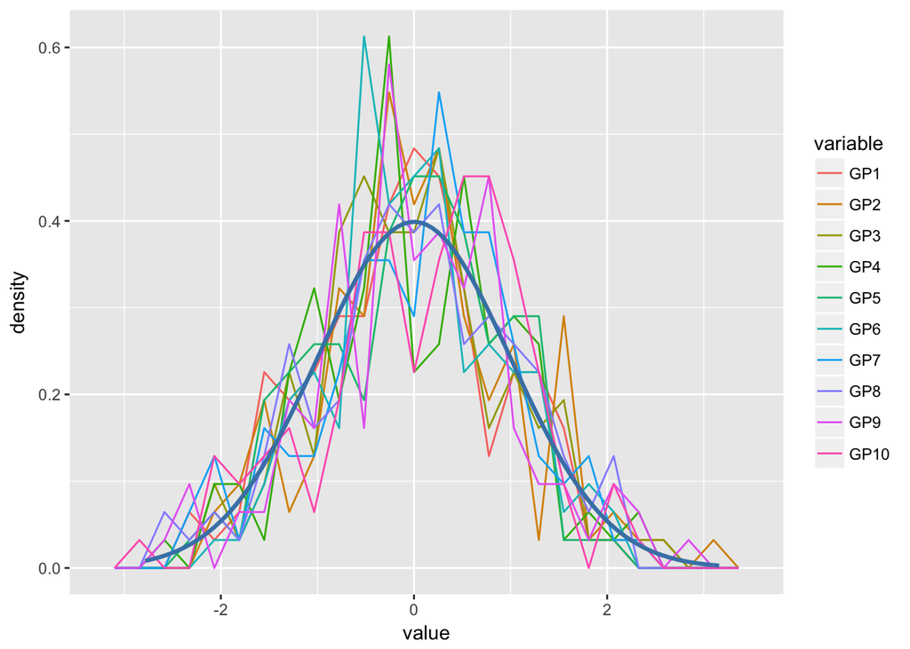

```r
plt = ggplot(plt_df_m) +
    geom_freqpoly(aes(value, ..density.., color=variable), bins=floor(D/5)) +
    stat_function(fun = dnorm, colour = "steelblue", size=1.1)
plt
```

## Another alternative kernel

For good measure, let’s look at another common kernel

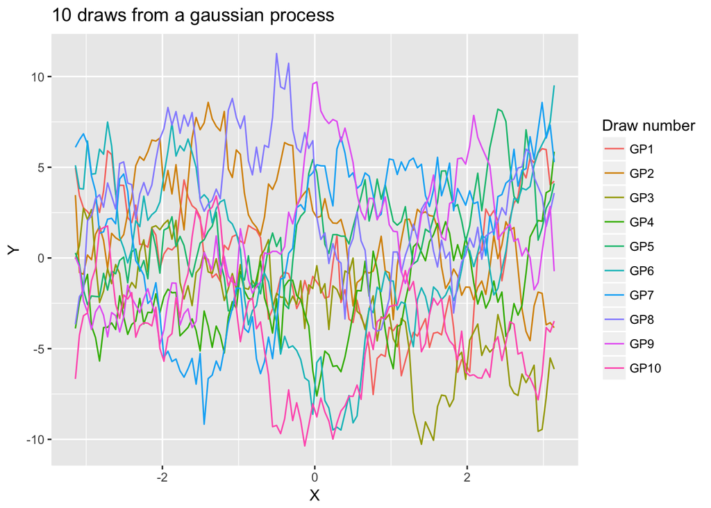

```r
kernel_abs = function(x0, x1){
    # Using exponential loss
    return(4^2 * exp(-1/2 * abs(x0-x1) / 0.5))
}

# Calculate covariance matrix
S = outer(xs, xs, kernel_abs)

# Draw joint multivariate gaussian samples
ys = t(mvrnorm(K, mu = mu(xs), Sigma=S))

# Plot
plt_df = data.frame(x=xs, y=ys)
names(plt_df) = c("x", paste("GP", 1:K, sep=""))
plt_df_m = melt(plt_df, id=c("x"))
plt = ggplot(plt_df_m) +
    geom_line(aes(x=x, y=value, color=variable)) +
    labs(x="X", y="Y",
         title=paste(K, "draws from a gaussian process"),
         color="Draw number")
```

# And now a simple application to regression

You may have noticed that I’m using a constant mean function $\mu(x) = 0$ for all $x$. Now, I’ll switch to a regression context where I’ll look at drawing sample functions from a gaussian process with a mean function set to the observed values of the function.

## Target function deffinition

For the sake of example, I’ll consider the target function
$$y = f(x) + \epsilon \quad {\rm where} \quad
f(x) = x^2 e^{-x^2} + {\rm sin}(x) \quad {\rm and} \quad
\epsilon \sim {\rm iid} N(0,\sigma_\epsilon)$$

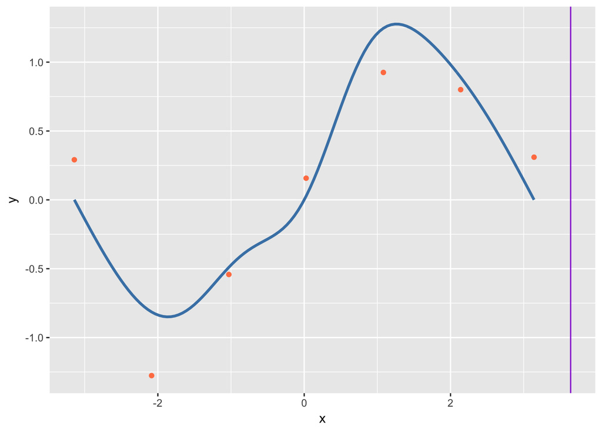

```r
# Parameters
M = 7 # number of points to observe from the model
# NOTE: that if this gets too big, inverting the covariance matrix can bevome
# numerically unstable resulting in failures to invert (which is ok) or wildly
# divergent estimates (which could be catastrophic).

# Heterogeneous mean function
mu = function(x){
    return(x^2 * exp(-x^2) + sin(x))
}

ys = mu(xs)
# ixs = base::sample(1:D, M)
ixs = ceiling(seq(1, D, length.out=M))
xsobv = xs[ixs]
ysobv = ys[ixs] + rnorm(M, sd=0.4)
xu = t[2] + 1/2

# Plot the true function and the observed points
plt = ggplot(data.frame(x=xs, y=ys)) +
    geom_line(aes(x=x, y=y), color="steelblue", size=1.1) +
    geom_point(data=data.frame(x=xsobv, y=ysobv), aes(x=x, y=y), color="coral") +
    geom_vline(xintercept=xu, color="darkviolet")
```

Next, I’ll try to regress a point not in the sample using gaussian proceess regression a.k.a. kreiging. The unknown point will be at $x=3.6415927$ depicted above by the violet vertical line.

## Regression at a point outside the support

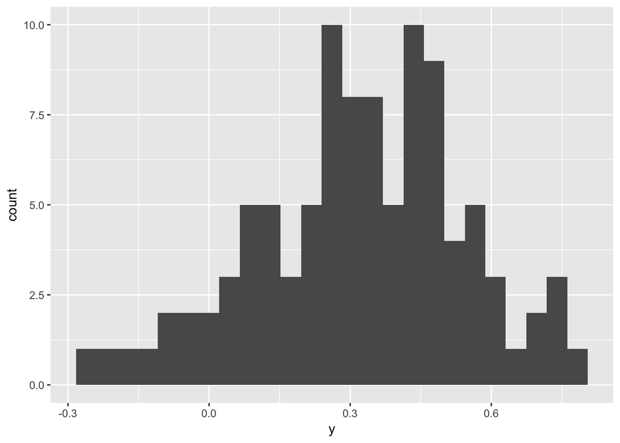

```r
gen_posterior = function(xu, xs, ys){
    ## Generates a posterior function

    # posterior probability f(yu | ys) = N(m, s)
    K0 = outer(xs, xs, kernel_sel) # kernel of the observed values
    K1 = outer(xu, xs, kernel_sel)
    K2 = outer(xu, xu, kernel_sel)
    K = rbind(cbind(K0, t(K1)), cbind(K1, K2))

    # mean and variance of posterior
    m = K1 %*% solve(K0) %*% ys
    s = K2 - K1 %*% solve(K0) %*% t(K1)

    return(
           function(n){
               mvrnorm(n, mu = m, Sigma = s)
           }
    )
}

posterior = gen_posterior(xu, xsobv, ysobv)

n = 100
post_obs = posterior(n)
plt_post = ggplot(data=data.frame(y=post_obs)) +
    geom_histogram(aes(x=y), bins=floor(n/4))
plt_post
```

## Posterior 90% credible band

Here I calculate the 90% posterior credible band which serves as a reigon of reasonable confidence for the location of the target curve. I calculate this band by drawing from the posterior at many points along the domain of the target function inside and beyond its sampling support. Insodoing I gather a sample of potential curves and calculate the emperical quantiles to recover the confidence band. Note that the analytical posterior 90% confidence band is trivially accessible via the gaussian process assumption and the form of the posterior distriution - the results shouldn’t be all that different in one dimension where the law of large numbers works quickly.

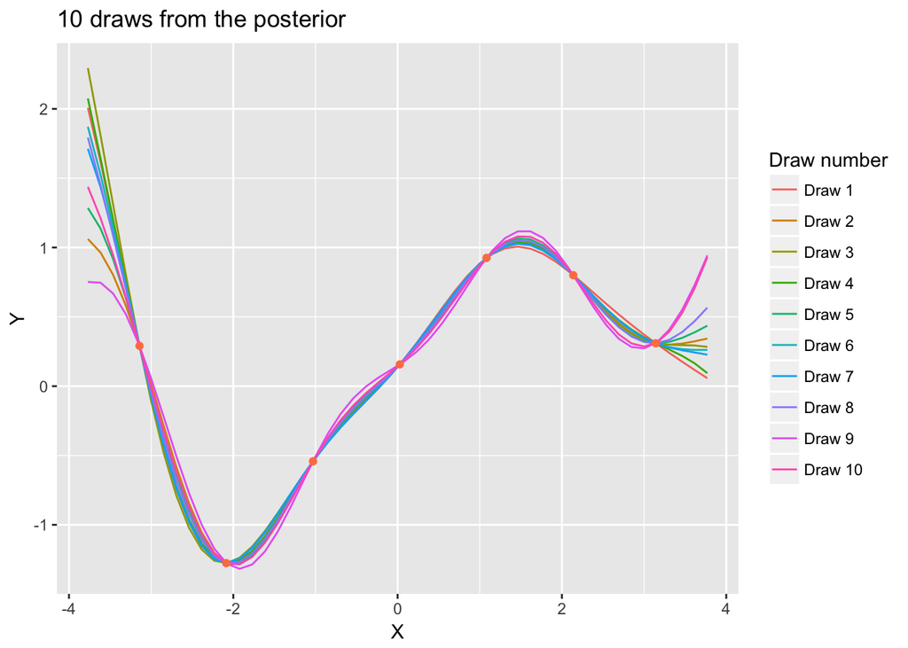

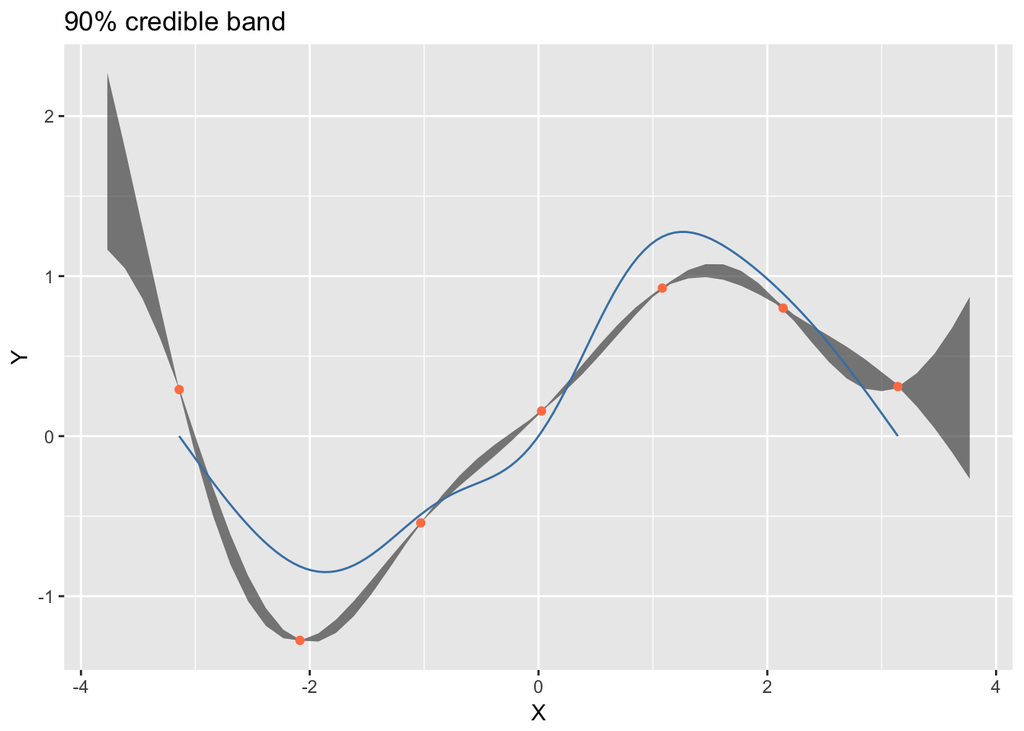

```r
# Parameters
m = 50 # resolution of the posterior
n = 10 # number of draws from the posterior
d = t[2] - t[1] # length of the sampling support

# Collocated posterior points
xus = seq(t[1] - d/10, t[2] + d/10, length.out=m)

# Draw from the posterior for an illustrative plot
posterior_multi = gen_posterior(xus, xsobv, ysobv)
draws = posterior_multi(n)

# Plot the aforementioned illustrative plot of draws from the posterior
df_post = data.frame(t(rbind(draws, xus)))
names(df_post) = c(paste("Draw", 1:n), "X")
df_post_m = melt(df_post, id="X")
plt_post = ggplot(df_post_m) +
    geom_line(aes(x=X, y=value, color=variable)) +
    geom_point(data=data.frame(x=xsobv, y=ysobv),
               aes(x=x, y=y),
               color="coral") +
    labs(x="X", y="Y", title=paste(n, "draws from the posterior"),
         color="Draw number")

# Draw for the emperical 90% band and calculate the band
n = 50
draws = posterior_multi(n)
qs = apply(t(draws), 1, (function(x) (return(quantile(x, c(0.05, 0.95))))))

# Plot the 90% band
df_post_band = data.frame(t(rbind(qs, xus)))
names(df_post_band) = c("q0", "q1", "X")
plt_post_band = ggplot(df_post_band) +
    geom_ribbon(aes(ymin=q0, ymax=q1, x=X), alpha=0.6) +
    geom_point(data=data.frame(x=xsobv, y=ysobv),
               aes(x=x, y=y),
               color="coral") +
    geom_line(data=data.frame(x=xs, y=ys), aes(x=x, y=y), color="steelblue") +
    labs(x="X", y="Y", title="90% credible band")

draws = posterior_multi(n)
```

# Sources

1. https://en.wikipedia.org/wiki/Gaussian_process
2. https://arxiv.org/abs/1505.02965
3. http://www.gaussianprocess.org/gpml/chapters/RW2.pdf